# loan_default_prediction

Bill

11/17/2020

# 1. Problem Definition

## 1.1 Defining the Question

Create a credit scoring model to predict whether a new customer will default based on the historical data in the given dataset. Select one or several suitable learning algorithms and a suitable metric for assessing quality model.

## 1.3 Defining the Metric of Success

Since the problem we are tackling is a classification problem, we will use classification reports and confusion matrices as well as accuracy and precision scores to measure the success of the models used.

## 1.4 Understanding the Context

Talar is a finance app that offers microloans to its users in Kenya, Philippines and Tanzania. It uses a variety of information, from basic biographical data to the loan applications that come through daily. You work with the product team as a data scientist to help create effective credit scoring models used to assess different customer segments

## 1.5 Experimental Design taken

- load libraries and dataset
- clean dataset:
  - deal with duplicate and/or missing values
  - deal with outliers, where necessary
  - deal with other anomalies in the data, where necessary
- carry out exploratory data analysis
- carry out feature engineering
- carry out modeling
- tune hyperparameters
- feature selection
- alternative models
- summarize and provide recommendations
- challenge the solution

# 2. Data Sourcing

The dataset was obtained from the AfterWork Fellowship Program Webinar where Credit Scoring Models were being explored

```r
## Loading packages that we will use during our analysis
library("dplyr")
library("purrr")
library('tidyverse')
library('magrittr')
library('corrplot')
library('caret')
library('skimr')
library(readr)
```

```r
train <- read_csv("datasets/train.csv")
## previewing first 6 rows
head(train)
```

```
## # A tibble: 6 x 19
##      id application_dt education_cd gender_cd   age car_own_flg car_type_flg
##   <dbl> <chr>          <chr>        <chr>     <dbl> <chr>       <chr>
## 1     1 01JAN2014      SCH          M            27 Y           Y
## 2     2 01JAN2014      GRD          F            26 N           N
## 3     3 01JAN2014      SCH          M            35 N           N
## 4     4 01JAN2014      GRD          F            35 N           N
## 5     5 01JAN2014      UGR          F            24 N           N
## 6     6 01JAN2014      SCH          M            35 Y           Y
## # ... with 12 more variables: appl_rej_cnt <dbl>, good_work_flg <dbl>,
## #   Score_bki <dbl>, out_request_cnt <dbl>, region_rating <dbl>,
## #   home_address_cd <dbl>, work_address_cd <dbl>, income <dbl>, SNA <dbl>,
## #   first_time_cd <dbl>, Air_flg <chr>, default_flg <dbl>
```

```r
##previewing the last 6 rows of the dataset
tail(train)
```

```
## # A tibble: 6 x 19
##       id application_dt education_cd gender_cd   age car_own_flg car_type_flg
##    <dbl> <chr>          <chr>        <chr>     <dbl> <chr>       <chr>
## 1 110143 30APR2014      GRD          F            42 N           N
## 2 110144 30APR2014      SCH          M            26 Y           Y
## 3 110145 30APR2014      GRD          F            39 N           N
## 4 110146 30APR2014      UGR          M            27 Y           N
## 5 110147 30APR2014      SCH          F            52 Y           N
## 6 110148 30APR2014      SCH          F            21 N           N
## # ... with 12 more variables: appl_rej_cnt <dbl>, good_work_flg <dbl>,
## #   Score_bki <dbl>, out_request_cnt <dbl>, region_rating <dbl>,
## #   home_address_cd <dbl>, work_address_cd <dbl>, income <dbl>, SNA <dbl>,
## #   first_time_cd <dbl>, Air_flg <chr>, default_flg <dbl>
```

Description of fields: ● id - an anonymous identifier of the applicant ● application_dt - application submission date ● sample_cd - sample category ● education_cd - education ● gender_cd - gender ● age - age of the applicant ● car_own_flg - vehicle presence flag ● car_type_flg - the foreign car presence flag ● appl_rej_cnt - the number of denied past claims ● good_work_flg - flag for “good” work ● Score_bki - a quick score based on data from the credit bureau ● out_request_cnt - number of requests in the bureau ● region_rating - rating of the region ● home_address_cd - home address categorizer ● work_address_cd - work address categorizer ● income - the income of the applicant ● SNA - the applicant’s relationship with customers ● first_time_cd - prescription of information about the applicant ● air_flg - presence of the passport passport ● default_flg - default credit flag - target variable

```r
## Previewing the shape of our dataset
dim(train)
```

```
## [1] 110148     19
```

```r
### we have 110148          rows and 19 columns!!!BAM!!

#checking the datatypes on the columns
sapply(train, class)
```

```
##              id  application_dt    education_cd       gender_cd             age
##       "numeric"     "character"     "character"     "character"       "numeric"
##     car_own_flg    car_type_flg    appl_rej_cnt   good_work_flg       Score_bki
##     "character"     "character"       "numeric"       "numeric"       "numeric"
## out_request_cnt   region_rating home_address_cd work_address_cd          income
##       "numeric"       "numeric"       "numeric"       "numeric"       "numeric"
##             SNA   first_time_cd         Air_flg     default_flg
##       "numeric"       "numeric"     "character"       "numeric"
```

```r
##checking for structure is using the str()
str(train)
```

```
## tibble [110,148 x 19] (S3: spec_tbl_df/tbl_df/tbl/data.frame)
##  $ id             : num [1:110148] 1 2 3 4 5 6 7 8 9 10 ...
##  $ application_dt : chr [1:110148] "01JAN2014" "01JAN2014" "01JAN2014" "01JAN2014" ...
##  $ education_cd   : chr [1:110148] "SCH" "GRD" "SCH" "GRD" ...
##  $ gender_cd      : chr [1:110148] "M" "F" "M" "F" ...
##  $ age            : num [1:110148] 27 26 35 35 24 35 35 55 34 42 ...
##  $ car_own_flg    : chr [1:110148] "Y" "N" "N" "N" ...
##  $ car_type_flg   : chr [1:110148] "Y" "N" "N" "N" ...
##  $ appl_rej_cnt   : num [1:110148] 0 0 0 0 0 0 0 0 0 0 ...
##  $ good_work_flg  : num [1:110148] 0 0 1 1 0 0 0 0 0 0 ...
##  $ Score_bki      : num [1:110148] -1.92 -1.15 -1.73 -2.55 -1.91 ...
##  $ out_request_cnt: num [1:110148] 0 2 0 2 1 4 6 1 2 3 ...
##  $ region_rating  : num [1:110148] 40 60 40 20 50 40 60 40 50 40 ...
##  $ home_address_cd: num [1:110148] 2 2 1 2 2 2 1 2 1 1 ...
##  $ work_address_cd: num [1:110148] 3 3 2 3 3 3 1 3 1 2 ...
##  $ income         : num [1:110148] 32000 50000 20000 80000 27000 35000 20000 8000 30000 60000 ...
##  $ SNA            : num [1:110148] 1 2 4 1 1 4 1 1 1 3 ...
##  $ first_time_cd  : num [1:110148] 4 1 3 3 2 3 3 3 4 3 ...
##  $ Air_flg        : chr [1:110148] "N" "N" "N" "N" ...
##  $ default_flg    : num [1:110148] 0 0 0 0 0 0 0 1 0 0 ...
##  - attr(*, "spec")=
##   .. cols(
##   ..   id = col_double(),
##   ..   application_dt = col_character(),
##   ..   education_cd = col_character(),
##   ..   gender_cd = col_character(),
##   ..   age = col_double(),
##   ..   car_own_flg = col_character(),
##   ..   car_type_flg = col_character(),
##   ..   appl_rej_cnt = col_double(),
##   ..   good_work_flg = col_double(),
##   ..   Score_bki = col_double(),
##   ..   out_request_cnt = col_double(),
##   ..   region_rating = col_double(),
##   ..   home_address_cd = col_double(),
##   ..   work_address_cd = col_double(),
##   ..   income = col_double(),
##   ..   SNA = col_double(),
##   ..   first_time_cd = col_double(),
##   ..   Air_flg = col_character(),
##   ..   default_flg = col_double()
##   .. )
```

```r
## We then a statistical summary of our dataset

summary(train)
```

```
##        id         application_dt     education_cd        gender_cd
##  Min.   :     1   Length:110148      Length:110148      Length:110148
##  1st Qu.: 27538   Class :character   Class :character   Class :character
##  Median : 55075   Mode  :character   Mode  :character   Mode  :character
##  Mean   : 55075
##  3rd Qu.: 82611
##  Max.   :110148
##       age        car_own_flg        car_type_flg        appl_rej_cnt
##  Min.   :21.00   Length:110148      Length:110148      Min.   : 0.0000
##  1st Qu.:30.00   Class :character   Class :character   1st Qu.: 0.0000
##  Median :37.00   Mode  :character   Mode  :character   Median : 0.0000
##  Mean   :39.25                                         Mean   : 0.2732
##  3rd Qu.:48.00                                         3rd Qu.: 0.0000
##  Max.   :72.00                                         Max.   :33.0000
##  good_work_flg      Score_bki       out_request_cnt  region_rating
##  Min.   :0.0000   Min.   :-3.6246   Min.   : 0.000   Min.   :20.00
##  1st Qu.:0.0000   1st Qu.:-2.2604   1st Qu.: 0.000   1st Qu.:50.00
##  Median :0.0000   Median :-1.9208   Median : 1.000   Median :50.00
##  Mean   :0.1655   Mean   :-1.9045   Mean   : 2.005   Mean   :56.75
##  3rd Qu.:0.0000   3rd Qu.:-1.5679   3rd Qu.: 3.000   3rd Qu.:60.00
##  Max.   :1.0000   Max.   : 0.1998   Max.   :53.000   Max.   :80.00
##  home_address_cd work_address_cd     income             SNA
##  Min.   :1.000   Min.   :1.000   Min.   :   1000   Min.   :1.000
##  1st Qu.:1.000   1st Qu.:2.000   1st Qu.:  20000   1st Qu.:1.000
##  Median :2.000   Median :3.000   Median :  30000   Median :1.000
##  Mean   :1.575   Mean   :2.498   Mean   :  41013   Mean   :1.732
##  3rd Qu.:2.000   3rd Qu.:3.000   3rd Qu.:  48000   3rd Qu.:2.000
##  Max.   :3.000   Max.   :3.000   Max.   :1000000   Max.   :4.000
##  first_time_cd     Air_flg           default_flg
##  Min.   :1.000   Length:110148      Min.   :0.0000
##  1st Qu.:2.000   Class :character   1st Qu.:0.0000
##  Median :3.000   Mode  :character   Median :0.0000
##  Mean   :2.766                      Mean   :0.1268
##  3rd Qu.:4.000                      3rd Qu.:0.0000
##  Max.   :4.000                      Max.   :1.0000
```

# check for duplicated values

```r
duplicated_rows<- train[duplicated(train),]

duplicated_rows
```

```
## # A tibble: 0 x 19
## # ... with 19 variables: id <dbl>, application_dt <chr>, education_cd <chr>,
## #   gender_cd <chr>, age <dbl>, car_own_flg <chr>, car_type_flg <chr>,
## #   appl_rej_cnt <dbl>, good_work_flg <dbl>, Score_bki <dbl>,
## #   out_request_cnt <dbl>, region_rating <dbl>, home_address_cd <dbl>,
## #   work_address_cd <dbl>, income <dbl>, SNA <dbl>, first_time_cd <dbl>,
## #   Air_flg <chr>, default_flg <dbl>
```

```r
##  No duplicates found
```

```r
# check for missing values

colSums(is.na(train))
```

```
##              id  application_dt    education_cd       gender_cd             age
##               0               0             478               0               0
##     car_own_flg    car_type_flg    appl_rej_cnt   good_work_flg       Score_bki
##               0               0               0               0               0
## out_request_cnt   region_rating home_address_cd work_address_cd          income
##               0               0               0               0               0
##             SNA   first_time_cd         Air_flg     default_flg
##               0               0               0               0
```

```r
##dropping missing values
train <- na.omit(train)
colSums(is.na(train))
```

```
##              id  application_dt    education_cd       gender_cd             age
##               0               0               0               0               0
##     car_own_flg    car_type_flg    appl_rej_cnt   good_work_flg       Score_bki
##               0               0               0               0               0
## out_request_cnt   region_rating home_address_cd work_address_cd          income
##               0               0               0               0               0
##             SNA   first_time_cd         Air_flg     default_flg
##               0               0               0               0
```

```r
# check the data types
#in R
sapply(train, class)
```

```
##              id  application_dt    education_cd       gender_cd             age
##       "numeric"     "character"     "character"     "character"       "numeric"
##     car_own_flg    car_type_flg    appl_rej_cnt   good_work_flg       Score_bki
##     "character"     "character"       "numeric"       "numeric"       "numeric"
## out_request_cnt   region_rating home_address_cd work_address_cd          income
##       "numeric"       "numeric"       "numeric"       "numeric"       "numeric"
##             SNA   first_time_cd         Air_flg     default_flg
##       "numeric"       "numeric"     "character"       "numeric"
```

We should split the ‘application_dt’ variable into day and month.

```r
#install.packages("anytime")
library(anytime)
train$application_dt <- anytime::anydate(train$application_dt)
head(train)
```

```
## # A tibble: 6 x 19
##      id application_dt education_cd gender_cd   age car_own_flg car_type_flg
##   <dbl> <date>         <chr>        <chr>     <dbl> <chr>       <chr>
## 1     1 2014-01-01     SCH          M            27 Y           Y
## 2     2 2014-01-01     GRD          F            26 N           N
## 3     3 2014-01-01     SCH          M            35 N           N
## 4     4 2014-01-01     GRD          F            35 N           N
## 5     5 2014-01-01     UGR          F            24 N           N
## 6     6 2014-01-01     SCH          M            35 Y           Y
## # ... with 12 more variables: appl_rej_cnt <dbl>, good_work_flg <dbl>,
## #   Score_bki <dbl>, out_request_cnt <dbl>, region_rating <dbl>,
## #   home_address_cd <dbl>, work_address_cd <dbl>, income <dbl>, SNA <dbl>,
## #   first_time_cd <dbl>, Air_flg <chr>, default_flg <dbl>
```

```r
train$month <- format(train$application_dt, format="%m")
train$day <- format(train$application_dt, format="%d")
#check the datatypes
tail(train)
```

```
## # A tibble: 6 x 21
##       id application_dt education_cd gender_cd   age car_own_flg car_type_flg
##    <dbl> <date>         <chr>        <chr>     <dbl> <chr>       <chr>
## 1 110143 2014-04-30     GRD          F            42 N           N
## 2 110144 2014-04-30     SCH          M            26 Y           Y
## 3 110145 2014-04-30     GRD          F            39 N           N
## 4 110146 2014-04-30     UGR          M            27 Y           N
## 5 110147 2014-04-30     SCH          F            52 Y           N
## 6 110148 2014-04-30     SCH          F            21 N           N
## # ... with 14 more variables: appl_rej_cnt <dbl>, good_work_flg <dbl>,
## #   Score_bki <dbl>, out_request_cnt <dbl>, region_rating <dbl>,
## #   home_address_cd <dbl>, work_address_cd <dbl>, income <dbl>, SNA <dbl>,
## #   first_time_cd <dbl>, Air_flg <chr>, default_flg <dbl>, month <chr>,
## #   day <chr>
```

```r
## obtaining numerical columns
numeric_columns <- unlist(lapply(train, is.numeric))

numeric_columns
```

```
##              id  application_dt    education_cd       gender_cd             age
##            TRUE           FALSE           FALSE           FALSE            TRUE
##     car_own_flg    car_type_flg    appl_rej_cnt   good_work_flg       Score_bki
##           FALSE           FALSE            TRUE            TRUE            TRUE
## out_request_cnt   region_rating home_address_cd work_address_cd          income
##            TRUE            TRUE            TRUE            TRUE            TRUE
##             SNA   first_time_cd         Air_flg     default_flg           month
##            TRUE            TRUE           FALSE            TRUE           FALSE
##             day
##           FALSE
```

```r
## I will put the numerical columns in a dataframe

columns_numeric <- train[ , numeric_columns]

head(columns_numeric)
```

```
## # A tibble: 6 x 13
##      id   age appl_rej_cnt good_work_flg Score_bki out_request_cnt region_rating
##   <dbl> <dbl>        <dbl>         <dbl>     <dbl>           <dbl>         <dbl>
## 1     1    27            0             0     -1.92               0            40
## 2     2    26            0             0     -1.15               2            60
## 3     3    35            0             1     -1.73               0            40
## 4     4    35            0             1     -2.55               2            20
## 5     5    24            0             0     -1.91               1            50
## 6     6    35            0             0     -1.92               4            40
## # ... with 6 more variables: home_address_cd <dbl>, work_address_cd <dbl>,
## #   income <dbl>, SNA <dbl>, first_time_cd <dbl>, default_flg <dbl>
```

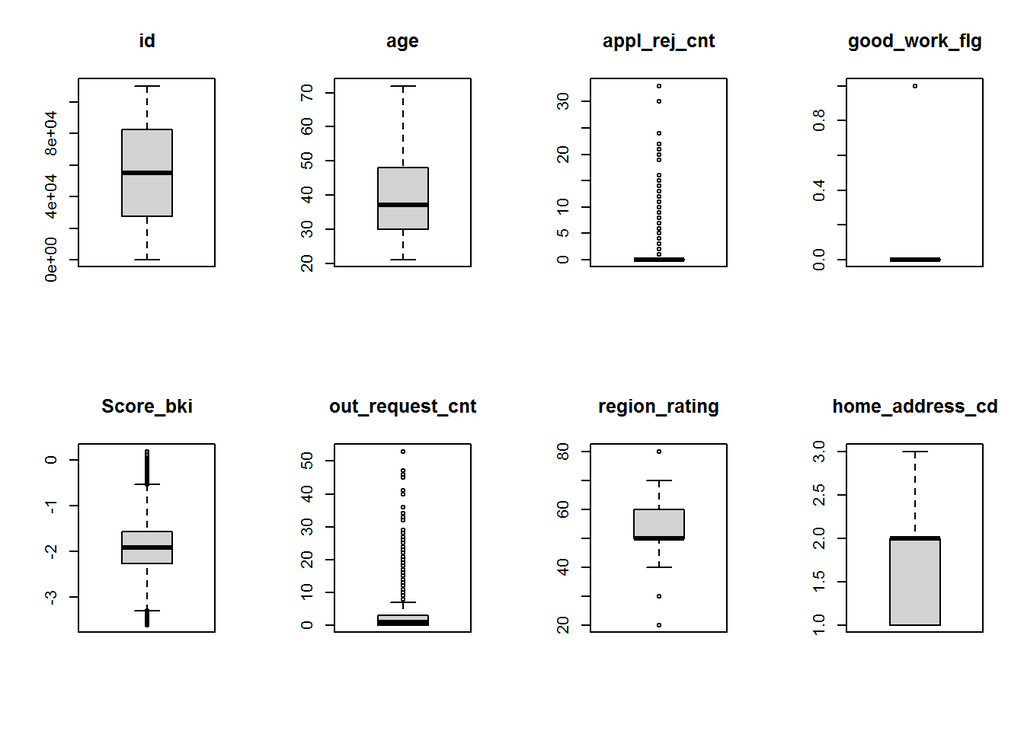

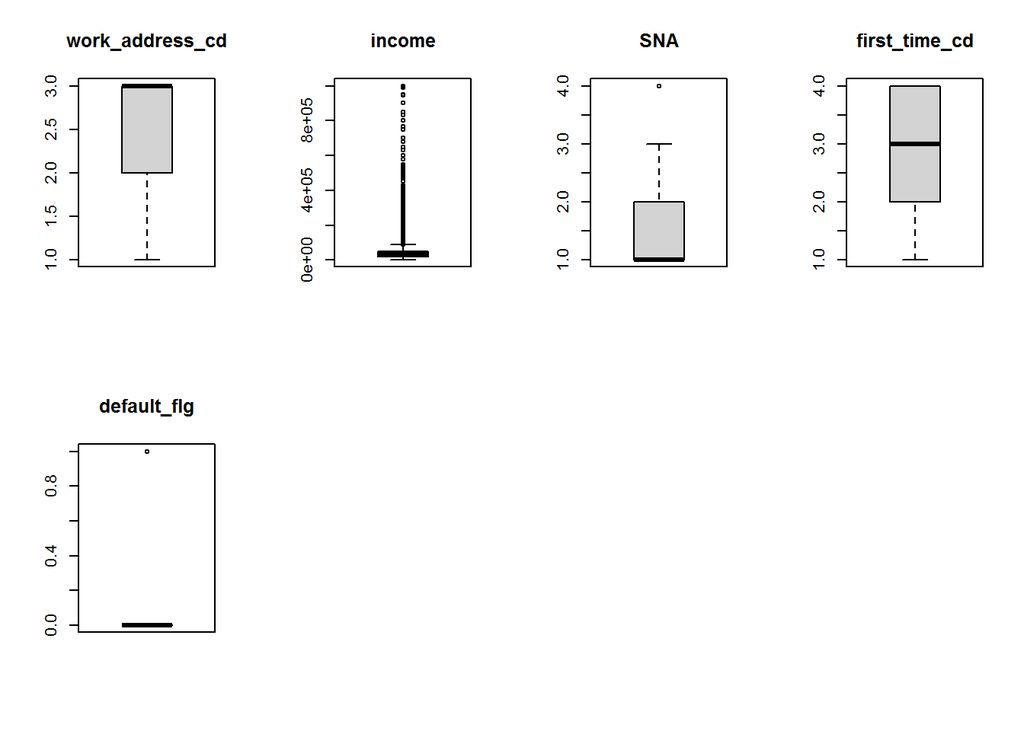

```r
# using a for lop, I will output boxplots of numerical columns..This will help me to identify the outliers

par ( mfrow= c (  2, 4 ))
for (i in 1 : length (columns_numeric)) {
boxplot (columns_numeric[,i], main= names (columns_numeric[i]), type= "l" )
}
```

_ We have outliers in our numerical columns but we wont drop them as they play a major role in our modelling

3. EDA ## Univariate Analysis

```r
# distribution of education

table(train$education_cd)
```

```
##
##   ACD   GRD   PGR   SCH   UGR
##   291 34768  1865 57998 14748
```

SCH has more applications followed by GRD

```r
# exploring the 'gender_cd' variable
table(train$gender_cd)
```

```
##
##     F     M
## 61576 48094
```

- More female apply for a loan than male

```r
# exploring the 'age variable'
table(train$age)
```

```
##
##   21   22   23   24   25   26   27   28   29   30   31   32   33   34   35   36
## 1260 1410 2287 2771 3282 3771 3954 4019 3929 4018 4077 3758 3488 3537 3365 3211
##   37   38   39   40   41   42   43   44   45   46   47   48   49   50   51   52
## 3169 3058 3073 2943 2790 2838 2653 2522 2223 2088 2065 2074 1953 2095 2006 2050
##   53   54   55   56   57   58   59   60   61   62   63   64   65   66   67   68
## 1969 1906 1831 1635 1569 1369 1334 1231  966  877  712  662  615  441  381  260
##   69   70   71   72
##  108   60    6    1
```

```r
# exploring the 'car_own_flg' variable
table(train$car_own_flg)
```

```
##
##     N     Y
## 74012 35658
```

- Most applicants do not have a car

```r
# exploring the 'car_type_flg' variable
table(train$car_type_flg)
```

```
##
##     N     Y
## 88739 20931
```

```r
# exploring the 'appl_rej_cnt' variable
table(train$appl_rej_cnt)
```

```
##
##     0     1     2     3     4     5     6     7     8     9    10    11    12
## 91033 12468  3617  1362   606   255   156    58    37    29    16    10     5
##    13    14    15    16    19    20    21    22    24    30    33
##     4     3     1     3     1     1     1     1     1     1     1
```

```r
# exploring the 'good_work_flg' variable
table(train$good_work_flg)
```

```
##
##     0     1
## 91507 18163
```

```r
head(train)
```

```
## # A tibble: 6 x 21
##      id application_dt education_cd gender_cd   age car_own_flg car_type_flg
##   <dbl> <date>         <chr>        <chr>     <dbl> <chr>       <chr>
## 1     1 2014-01-01     SCH          M            27 Y           Y
## 2     2 2014-01-01     GRD          F            26 N           N
## 3     3 2014-01-01     SCH          M            35 N           N
## 4     4 2014-01-01     GRD          F            35 N           N
## 5     5 2014-01-01     UGR          F            24 N           N
## 6     6 2014-01-01     SCH          M            35 Y           Y
## # ... with 14 more variables: appl_rej_cnt <dbl>, good_work_flg <dbl>,
## #   Score_bki <dbl>, out_request_cnt <dbl>, region_rating <dbl>,
## #   home_address_cd <dbl>, work_address_cd <dbl>, income <dbl>, SNA <dbl>,
## #   first_time_cd <dbl>, Air_flg <chr>, default_flg <dbl>, month <chr>,
## #   day <chr>
```

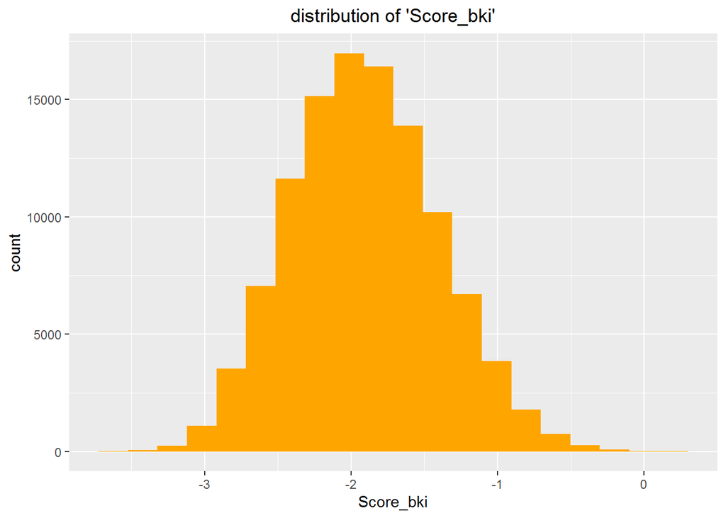

```r
# plot the distribution of 'Score_bki'
#install.packages("tidyverse")
library(tidyverse)
ggplot(data = train, mapping = aes(x = Score_bki)) +
  geom_histogram(bins = 20, fill = "orange") +
  #labs(x = "Distribution of sales") +
  ggtitle("distribution of 'Score_bki'") +
  theme(plot.title = element_text(hjust = 0.5))
```

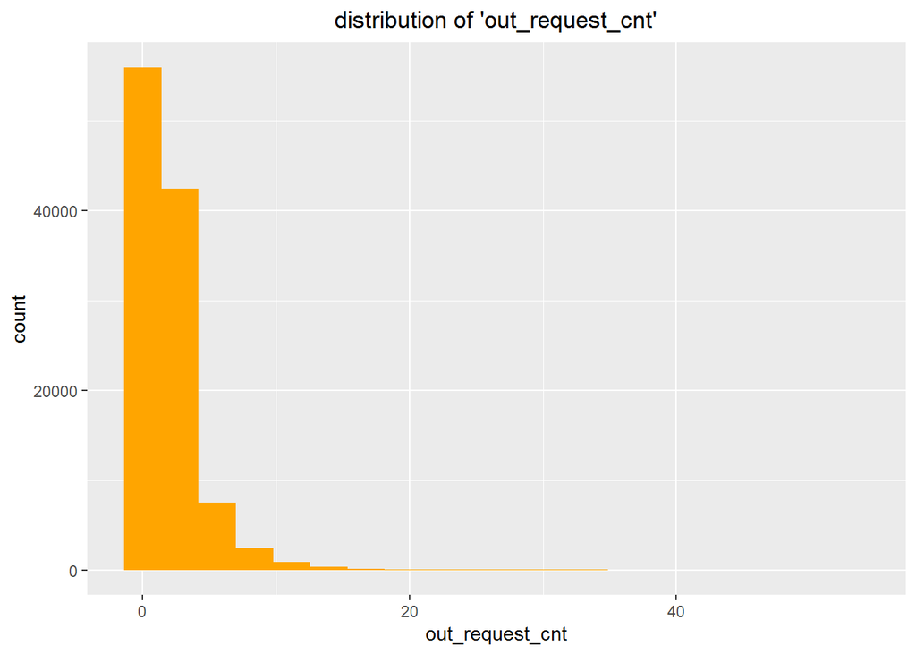

```r
# exploring the 'out_request_cnt' variable
# plot the distribution of 'out_request_cnt'
#install.packages("tidyverse")
library(tidyverse)
ggplot(data = train, mapping = aes(x = out_request_cnt)) +
  geom_histogram(bins = 20, fill = "orange") +
  #labs(x = "Distribution of sales") +
  ggtitle("distribution of 'out_request_cnt'") +
  theme(plot.title = element_text(hjust = 0.5))
```

```r
# exploring the 'region_rating' variable
table(train$region_rating)
```

```
##
##    20    30    40    50    60    70    80
##   313   431 17877 40834 23917  9268 17030
```

```r
# exploring the 'region_rating' variable per default
table(train$region_rating, train$default_flg)
```

```
##
##          0     1
##   20   249    64
##   30   355    76
##   40 14833  3044
##   50 35211  5623
##   60 20891  3026
##   70  8414   854
##   80 15807  1223
```

```r
# subsetting to get the nuerical columns only
numeric_columns <- unlist(lapply(train, is.numeric))
numeric_columns
```

```
##              id  application_dt    education_cd       gender_cd             age
##            TRUE           FALSE           FALSE           FALSE            TRUE
##     car_own_flg    car_type_flg    appl_rej_cnt   good_work_flg       Score_bki
##           FALSE           FALSE            TRUE            TRUE            TRUE
## out_request_cnt   region_rating home_address_cd work_address_cd          income
##            TRUE            TRUE            TRUE            TRUE            TRUE
##             SNA   first_time_cd         Air_flg     default_flg           month
##            TRUE            TRUE           FALSE            TRUE           FALSE
##             day
##           FALSE
```

3.2. Bivariate Analysis

- We will investigate how the target variable relates to the other variables.

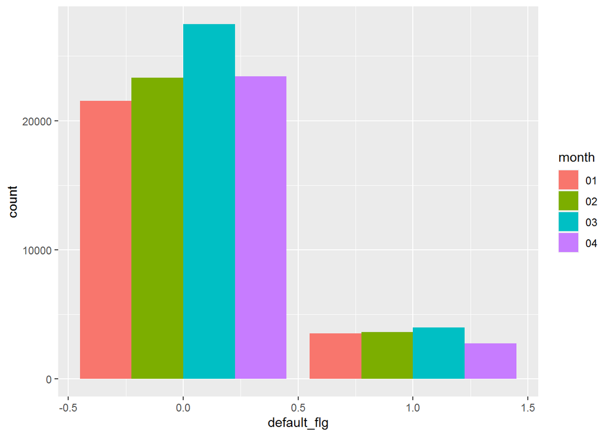

```r
# default_flg by application_month
ggplot(data = train) +
  geom_bar(mapping = aes(x = default_flg, fill =month ), position = "dodge")
```

- Default is higher in March

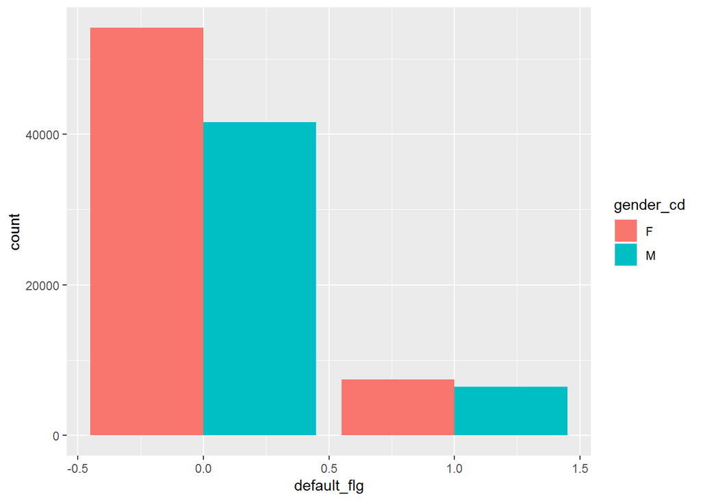

```r
# default_flg by gender_cd
ggplot(data = train) +
  geom_bar(mapping = aes(x = default_flg, fill =gender_cd ), position = "dodge")
```

- The cases of default is higher in females compared to males

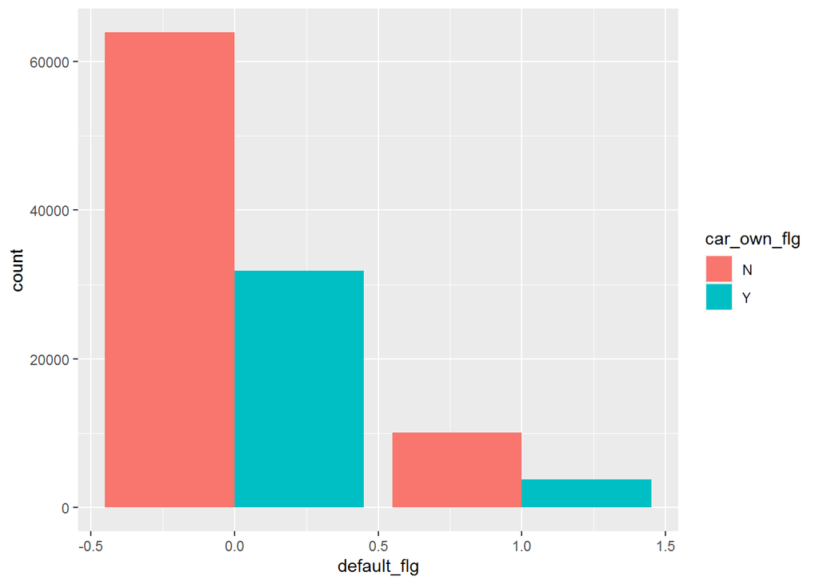

```r
# default_flg by car_own_flg
ggplot(data = train) +
  geom_bar(mapping = aes(x = default_flg, fill =car_own_flg ), position = "dodge")
```

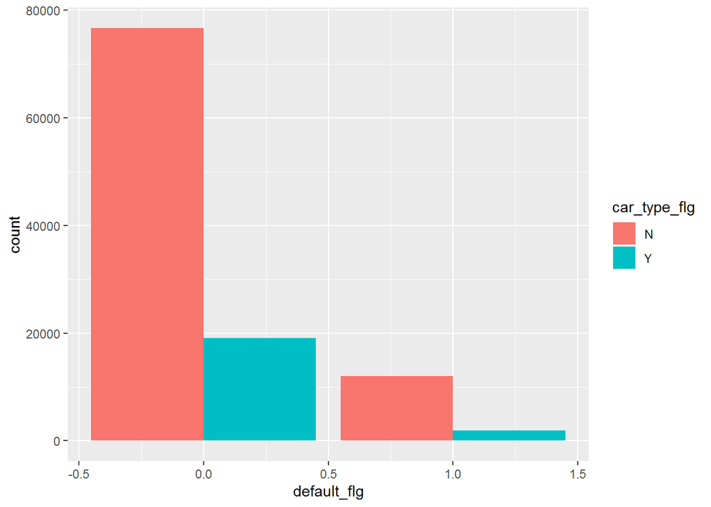

```r
# default_flg by car_type_flg
ggplot(data = train) +
  geom_bar(mapping = aes(x = default_flg, fill =car_type_flg ), position = "dodge")
```

- non foreign cars have most default cases

```r
# default_flg by region_rating
region_rating2 <- table(train$region_rating, train$default_flg)
names(dimnames(region_rating2)) <- c("region_rating", "default_flg")
region_rating2
```

```
##              default_flg
## region_rating     0     1
##            20   249    64
##            30   355    76
##            40 14833  3044
##            50 35211  5623
##            60 20891  3026
##            70  8414   854
##            80 15807  1223
```

- Region 50 has the most defaulters

```r
# default_flg by education_Cd
education <- table(train$education_cd, train$default_flg)
names(dimnames(education)) <- c("education_cd", "default_flg")
education
```

```
##             default_flg
## education_cd     0     1
##          ACD   277    14
##          GRD 31682  3086
##          PGR  1745   120
##          SCH 49228  8770
##          UGR 12828  1920
```

```r
# default_flg by first_time_cd

first_time_cd2 <- table(train$first_time_cd, train$default_flg)
names(dimnames(first_time_cd2)) <- c("first_time_cd2", "default_flg")
first_time_cd2
```

```
##               default_flg
## first_time_cd2     0     1
##              1 14832  3388
##              2 14525  2661
##              3 40866  5549
##              4 25537  2312
```

- On the third loan most defaulted payment

```r
# default_flg by Air_flg
Air_flg2 <- table(train$Air_flg, train$default_flg)
names(dimnames(Air_flg2)) <- c("Air_flg", "default_flg")
Air_flg2
```

```
##        default_flg
## Air_flg     0     1
##       N 80654 12672
##       Y 15106  1238
```

- Non passport holders holders were most defaulters

# default_flg by region by outrequest

```r
out_request1 <- table(train$default_flg, train$region_rating, train$out_request_cnt)
names(dimnames(out_request1)) <- c("default_flg", "region_rating", "out_request_cnt")
out_request1
```

```
## , , out_request_cnt = 0
##
##            region_rating
## default_flg   20   30   40   50   60   70   80
##           0   60   95 3782 9446 5384 2366 4907
##           1    8   11  609 1115  568  164  242
##
## , , out_request_cnt = 1
##
##            region_rating
## default_flg   20   30   40   50   60   70   80
##           0   63   81 3824 8960 5335 1849 3838
##           1   19   27  713 1276  725  182  282
##
## , , out_request_cnt = 2
##
##            region_rating
## default_flg   20   30   40   50   60   70   80
##           0   46   73 2894 6547 4020 1424 2689
##           1   20   17  606 1078  588  157  231
##
## , , out_request_cnt = 3
##
##            region_rating
## default_flg   20   30   40   50   60   70   80
##           0   41   51 1859 4371 2566 1056 1712
##           1    7   12  462  802  414  123  146
##
## , , out_request_cnt = 4
##
##            region_rating
## default_flg   20   30   40   50   60   70   80
##           0   18   25 1126 2643 1584  708 1024
##           1    6    3  277  476  295   90  106
##
## , , out_request_cnt = 5
##
##            region_rating
## default_flg   20   30   40   50   60   70   80
##           0   11   10  659 1494  906  387  627
```

[output cut: 224 more lines]

```
##           1    0    0    0    1    0    0    0
##
## , , out_request_cnt = 47
##
##            region_rating
## default_flg   20   30   40   50   60   70   80
##           0    0    0    0    0    0    0    0
##           1    0    0    0    0    1    0    0
##
## , , out_request_cnt = 53
##
##            region_rating
## default_flg   20   30   40   50   60   70   80
##           0    0    0    0    0    1    0    0
##           1    0    0    0    0    0    0    0
```

```r
# default_flg by age
age2 <- table(train$age, train$default_flg)
names(dimnames(age2)) <- c("age", "default_flg")
age2
```

```
##     default_flg
## age     0    1
##   21 1079  181
##   22 1198  212
##   23 1961  326
##   24 2394  377
##   25 2813  469
##   26 3219  552
##   27 3398  556
##   28 3477  542
##   29 3379  550
##   30 3496  522
##   31 3549  528
##   32 3284  474
##   33 3019  469
```

[output cut: 39 more lines]

- From 26 to 31 are the most defaulters

```r
# default_flg by income
income2 <- table(train$income, train$default_flg)
names(dimnames(income2)) <- c("income", "default_flg")
income2
```

```
##         default_flg
## income      0    1
##   1000      6    0
##   1100      1    0
##   1200      0    1
##   1500      2    0
##   1700      1    0
##   2000      1    1
##   2400      3    0
##   2450      1    0
##   2500      2    0
##   3000      8    0
##   3073      1    0
##   3500      2    0
##   3700      0    1
```

[output cut: 1193 more lines]

- Less than 30,000 income is a high risk

##Correlation matrix of all numerical columns

```r
correlations <- cor(columns_numeric, method = "pearson")

round(correlations, 2)
```

```
##                    id   age appl_rej_cnt good_work_flg Score_bki
## id               1.00  0.02        -0.02          0.00     -0.06
## age              0.02  1.00        -0.11         -0.07     -0.10
## appl_rej_cnt    -0.02 -0.11         1.00         -0.03      0.19
## good_work_flg    0.00 -0.07        -0.03          1.00      0.00
## Score_bki       -0.06 -0.10         0.19          0.00      1.00
## out_request_cnt -0.03  0.05         0.16          0.01      0.16
## region_rating    0.01 -0.09        -0.04          0.07      0.01
## home_address_cd  0.16  0.01         0.01         -0.01      0.02
## work_address_cd  0.16  0.00         0.02         -0.01      0.02
## income           0.00 -0.02        -0.02          0.03     -0.01
## SNA              0.00 -0.06         0.06         -0.05      0.07
## first_time_cd    0.02  0.08        -0.07          0.06     -0.07
## default_flg     -0.04 -0.03         0.11         -0.05      0.17
##                 out_request_cnt region_rating home_address_cd work_address_cd
## id                        -0.03          0.01            0.16            0.16
## age                        0.05         -0.09            0.01            0.00
## appl_rej_cnt               0.16         -0.04            0.01            0.02
## good_work_flg              0.01          0.07           -0.01           -0.01
## Score_bki                  0.16          0.01            0.02            0.02
## out_request_cnt            1.00          0.01            0.01            0.00
## region_rating              0.01          1.00            0.23            0.25
## home_address_cd            0.01          0.23            1.00            0.73
## work_address_cd            0.00          0.25            0.73            1.00
## income                     0.08          0.21            0.04            0.05
## SNA                        0.00         -0.08            0.11            0.11
## first_time_cd              0.01          0.09           -0.06           -0.06
## default_flg                0.08         -0.09            0.08            0.08
##                 income   SNA first_time_cd default_flg
## id                0.00  0.00          0.02       -0.04
## age              -0.02 -0.06          0.08       -0.03
## appl_rej_cnt     -0.02  0.06         -0.07        0.11
## good_work_flg     0.03 -0.05          0.06       -0.05
## Score_bki        -0.01  0.07         -0.07        0.17
## out_request_cnt   0.08  0.00          0.01        0.08
## region_rating     0.21 -0.08          0.09       -0.09
## home_address_cd   0.04  0.11         -0.06        0.08
## work_address_cd   0.05  0.11         -0.06        0.08
## income            1.00 -0.09          0.11       -0.04
## SNA              -0.09  1.00         -0.53        0.13
## first_time_cd     0.11 -0.53          1.00       -0.10
## default_flg      -0.04  0.13         -0.10        1.00
```

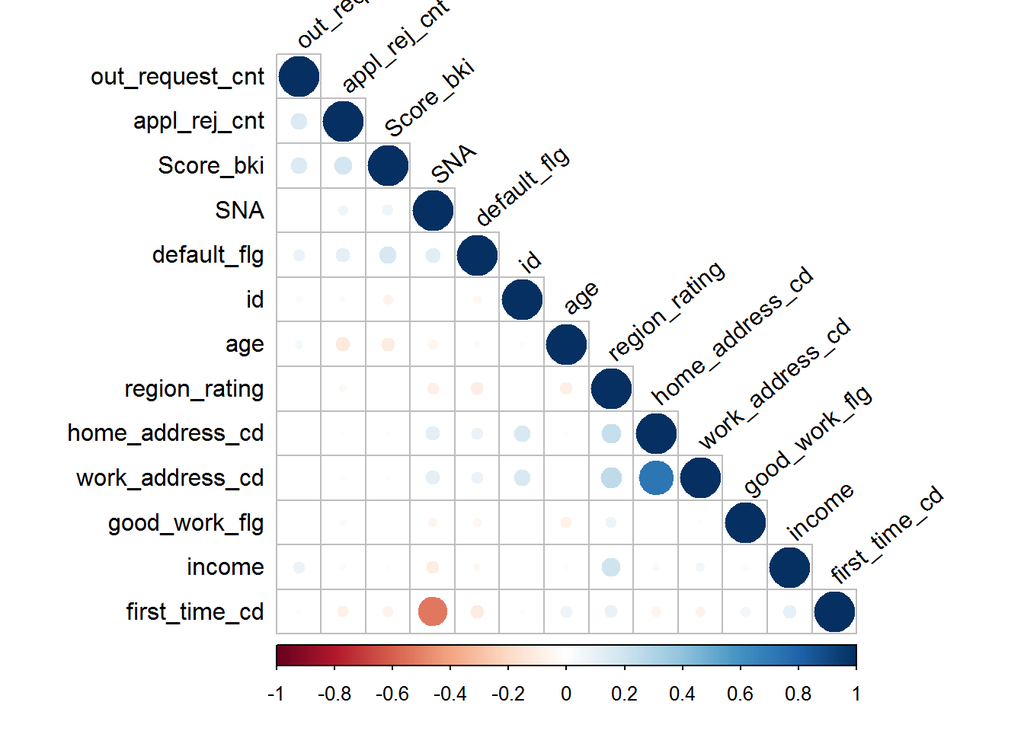

```r
library('corrplot')
corrplot(correlations, type = "lower", order = "hclust",tl.col = "black", tl.srt = 40)
```

## Observations Most of our colums have a weak correlation to the default_flg column

### Feature Engineering

```r
# binning our numerical variables
# binning age
min(train$age); max(train$age)
```

```
## [1] 21
```

```
## [1] 72
```

```r
age2 <- floor(runif(18, min = 21 , max = 72))
age2
```

```
##  [1] 59 33 58 68 58 47 33 56 45 27 24 33 63 64 30 24 47 56
```

```r
# binning Score_bki
min(train$Score_bki); max(train$Score_bki)
```

```
## [1] -3.624586
```

```
## [1] 0.1997729
```

```r
Score <- floor(runif(18, min = -3.624586 , max = 0.1997729))
Score
```

```
##  [1] -4 -4 -3 -2 -1 -3 -4 -3 -3 -2 -1 -2 -2 -3 -3 -3 -2 -1
```

```r
# binning income
min(train$income); max(train$income)
```

```
## [1] 1000
```

```
## [1] 1e+06
```

```r
income1 <- floor(runif(18, min = 1000 , max = 1e+06))
income1
```

```
##  [1] 958160  17782 887998 278532 677032 547394 163354 740105 571394 971073
## [11] 712495 427682  39356 117937 915036 986081 905700 367594
```

```r
# set day and month to factors dtype
colnames(train)
```

```
##  [1] "id"              "application_dt"  "education_cd"    "gender_cd"
##  [5] "age"             "car_own_flg"     "car_type_flg"    "appl_rej_cnt"
##  [9] "good_work_flg"   "Score_bki"       "out_request_cnt" "region_rating"
## [13] "home_address_cd" "work_address_cd" "income"          "SNA"
## [17] "first_time_cd"   "Air_flg"         "default_flg"     "month"
## [21] "day"
```

```r
train$day<-as.factor(train$day)
train$month<-as.factor(train$month)

str(train)
```

```
## tibble [109,670 x 21] (S3: tbl_df/tbl/data.frame)
##  $ id             : num [1:109670] 1 2 3 4 5 6 7 8 9 10 ...
##  $ application_dt : Date[1:109670], format: "2014-01-01" "2014-01-01" ...
##  $ education_cd   : chr [1:109670] "SCH" "GRD" "SCH" "GRD" ...
##  $ gender_cd      : chr [1:109670] "M" "F" "M" "F" ...
##  $ age            : num [1:109670] 27 26 35 35 24 35 35 55 34 42 ...
##  $ car_own_flg    : chr [1:109670] "Y" "N" "N" "N" ...
##  $ car_type_flg   : chr [1:109670] "Y" "N" "N" "N" ...
##  $ appl_rej_cnt   : num [1:109670] 0 0 0 0 0 0 0 0 0 0 ...
##  $ good_work_flg  : num [1:109670] 0 0 1 1 0 0 0 0 0 0 ...
##  $ Score_bki      : num [1:109670] -1.92 -1.15 -1.73 -2.55 -1.91 ...
##  $ out_request_cnt: num [1:109670] 0 2 0 2 1 4 6 1 2 3 ...
##  $ region_rating  : num [1:109670] 40 60 40 20 50 40 60 40 50 40 ...
##  $ home_address_cd: num [1:109670] 2 2 1 2 2 2 1 2 1 1 ...
##  $ work_address_cd: num [1:109670] 3 3 2 3 3 3 1 3 1 2 ...
##  $ income         : num [1:109670] 32000 50000 20000 80000 27000 35000 20000 8000 30000 60000 ...
##  $ SNA            : num [1:109670] 1 2 4 1 1 4 1 1 1 3 ...
##  $ first_time_cd  : num [1:109670] 4 1 3 3 2 3 3 3 4 3 ...
##  $ Air_flg        : chr [1:109670] "N" "N" "N" "N" ...
##  $ default_flg    : num [1:109670] 0 0 0 0 0 0 0 1 0 0 ...
##  $ month          : Factor w/ 4 levels "01","02","03",..: 1 1 1 1 1 1 1 1 1 1 ...
##  $ day            : Factor w/ 31 levels "01","02","03",..: 1 1 1 1 1 1 1 1 1 1 ...
##  - attr(*, "na.action")= 'omit' Named int [1:478] 1077 1525 1528 1534 1558 1645 1647 1756 1760 1781 ...
##   ..- attr(*, "names")= chr [1:478] "1077" "1525" "1528" "1534" ...
```

```r
head(train)
```

```
## # A tibble: 6 x 21
##      id application_dt education_cd gender_cd   age car_own_flg car_type_flg
##   <dbl> <date>         <chr>        <chr>     <dbl> <chr>       <chr>
## 1     1 2014-01-01     SCH          M            27 Y           Y
## 2     2 2014-01-01     GRD          F            26 N           N
## 3     3 2014-01-01     SCH          M            35 N           N
## 4     4 2014-01-01     GRD          F            35 N           N
## 5     5 2014-01-01     UGR          F            24 N           N
## 6     6 2014-01-01     SCH          M            35 Y           Y
## # ... with 14 more variables: appl_rej_cnt <dbl>, good_work_flg <dbl>,
## #   Score_bki <dbl>, out_request_cnt <dbl>, region_rating <dbl>,
## #   home_address_cd <dbl>, work_address_cd <dbl>, income <dbl>, SNA <dbl>,
## #   first_time_cd <dbl>, Air_flg <chr>, default_flg <dbl>, month <fct>,
## #   day <fct>
```

```r
# creating dummy variables of our categorical variables via one hot encoding
# encoding education_cd

train$education_cd <- as.integer(as.factor(train$education_cd))
# encoding gender_cd

train$gender_cd <- as.integer(as.factor(train$gender_cd))
# encoding car_own_flg

train$car_own_flg <- as.integer(as.factor(train$car_own_flg))

# encoding car_type_flg

train$car_type_flg <- as.integer(as.factor(train$car_type_flg))

# encoding Air_flg

train$Air_flg <- as.integer(as.factor(train$Air_flg))
# encoding age

train$age <- as.integer(as.factor(train$age))
# encoding Score_bki

train$Score_bki <- as.integer(as.factor(train$Score_bki))
# encoding income

train$income <- as.integer(as.factor(train$income))
train$month <- as.integer(as.factor(train$month))
train$day <- as.integer(as.factor(train$day))

head(train)
```

```
## # A tibble: 6 x 21
##      id application_dt education_cd gender_cd   age car_own_flg car_type_flg
##   <dbl> <date>                <int>     <int> <int>       <int>        <int>
## 1     1 2014-01-01                4         2     7           2            2
## 2     2 2014-01-01                2         1     6           1            1
## 3     3 2014-01-01                4         2    15           1            1
## 4     4 2014-01-01                2         1    15           1            1
## 5     5 2014-01-01                5         1     4           1            1
## 6     6 2014-01-01                4         2    15           2            2
## # ... with 14 more variables: appl_rej_cnt <dbl>, good_work_flg <dbl>,
## #   Score_bki <int>, out_request_cnt <dbl>, region_rating <dbl>,
## #   home_address_cd <dbl>, work_address_cd <dbl>, income <int>, SNA <dbl>,
## #   first_time_cd <dbl>, Air_flg <int>, default_flg <dbl>, month <int>,
## #   day <int>
```

```r
# dropping the unneeded columns
train$application_dt<- NULL
head(train)
```

```
## # A tibble: 6 x 20
##      id education_cd gender_cd   age car_own_flg car_type_flg appl_rej_cnt
##   <dbl>        <int>     <int> <int>       <int>        <int>        <dbl>
## 1     1            4         2     7           2            2            0
## 2     2            2         1     6           1            1            0
## 3     3            4         2    15           1            1            0
## 4     4            2         1    15           1            1            0
## 5     5            5         1     4           1            1            0
## 6     6            4         2    15           2            2            0
## # ... with 13 more variables: good_work_flg <dbl>, Score_bki <int>,
## #   out_request_cnt <dbl>, region_rating <dbl>, home_address_cd <dbl>,
## #   work_address_cd <dbl>, income <int>, SNA <dbl>, first_time_cd <dbl>,
## #   Air_flg <int>, default_flg <dbl>, month <int>, day <int>
```

4. Modelling

## KNN

```r
dim(train)
```

```
## [1] 109670     20
```

```r
# Randomizing the rows, creates a uniform distribution of 109670
set.seed(1234)
random <- runif(109670)

train_random <- train[order(random),]
# Selecting the first 6 rows from iris_random
head(train_random)
```

```
## # A tibble: 6 x 20
##      id education_cd gender_cd   age car_own_flg car_type_flg appl_rej_cnt
##   <dbl>        <int>     <int> <int>       <int>        <int>        <dbl>
## 1 99089            2         1    26           1            1            0
## 2 35974            4         2    16           1            1            1
## 3 78088            5         1     9           1            1            1
## 4 51084            2         1    14           1            1            0
## 5 25030            4         1    17           1            1            2
## 6 86282            5         1    38           1            1            1
## # ... with 13 more variables: good_work_flg <dbl>, Score_bki <int>,
## #   out_request_cnt <dbl>, region_rating <dbl>, home_address_cd <dbl>,
## #   work_address_cd <dbl>, income <int>, SNA <dbl>, first_time_cd <dbl>,
## #   Air_flg <int>, default_flg <dbl>, month <int>, day <int>
```

```r
##B4 normalizing, lets drop columns we dont need
train_random <- subset(train_random, select = -c(1))
head(train_random)
```

```
## # A tibble: 6 x 19
##   education_cd gender_cd   age car_own_flg car_type_flg appl_rej_cnt
##          <int>     <int> <int>       <int>        <int>        <dbl>
## 1            2         1    26           1            1            0
## 2            4         2    16           1            1            1
## 3            5         1     9           1            1            1
## 4            2         1    14           1            1            0
## 5            4         1    17           1            1            2
## 6            5         1    38           1            1            1
## # ... with 13 more variables: good_work_flg <dbl>, Score_bki <int>,
## #   out_request_cnt <dbl>, region_rating <dbl>, home_address_cd <dbl>,
## #   work_address_cd <dbl>, income <int>, SNA <dbl>, first_time_cd <dbl>,
## #   Air_flg <int>, default_flg <dbl>, month <int>, day <int>
```

```r
# Normalizing the numerical variables of the data set. Normalizing the numerical values is really effective for algorithms,
# as it provides a measure from 0 to 1 which corresponds to min value to the max value of the data column.
# We define a normal function which will normalize the set of values according to its minimum value and maximum value.
normal <- function(x) (
  return( ((x - min(x)) /(max(x)-min(x))) )
)

normal(1:5)
```

```
## [1] 0.00 0.25 0.50 0.75 1.00
```

```r
##rearranging the columns



train_random1<- train_random %>% relocate(default_flg, .after = last_col())

head(train_random1)
```

```
## # A tibble: 6 x 19
##   education_cd gender_cd   age car_own_flg car_type_flg appl_rej_cnt
##          <int>     <int> <int>       <int>        <int>        <dbl>
## 1            2         1    26           1            1            0
## 2            4         2    16           1            1            1
## 3            5         1     9           1            1            1
## 4            2         1    14           1            1            0
## 5            4         1    17           1            1            2
## 6            5         1    38           1            1            1
## # ... with 13 more variables: good_work_flg <dbl>, Score_bki <int>,
## #   out_request_cnt <dbl>, region_rating <dbl>, home_address_cd <dbl>,
## #   work_address_cd <dbl>, income <int>, SNA <dbl>, first_time_cd <dbl>,
## #   Air_flg <int>, month <int>, day <int>, default_flg <dbl>
```

```r
dim(train_random1)
```

```
## [1] 109670     19
```

```r
train_random1$id<- NULL
dim(train_random1)
```

```
## [1] 109670     19
```

```r
new_train <- as.data.frame(lapply(train_random1[, c(1:18)], normal))

summary(new_train)
```

```
##   education_cd      gender_cd           age          car_own_flg
##  Min.   :0.0000   Min.   :0.0000   Min.   :0.0000   Min.   :0.0000
##  1st Qu.:0.2500   1st Qu.:0.0000   1st Qu.:0.1765   1st Qu.:0.0000
##  Median :0.7500   Median :0.0000   Median :0.3137   Median :0.0000
##  Mean   :0.6189   Mean   :0.4385   Mean   :0.3576   Mean   :0.3251
##  3rd Qu.:0.7500   3rd Qu.:1.0000   3rd Qu.:0.5294   3rd Qu.:1.0000
##  Max.   :1.0000   Max.   :1.0000   Max.   :1.0000   Max.   :1.0000
##   car_type_flg     appl_rej_cnt      good_work_flg      Score_bki
##  Min.   :0.0000   Min.   :0.000000   Min.   :0.0000   Min.   :0.0000
##  1st Qu.:0.0000   1st Qu.:0.000000   1st Qu.:0.0000   1st Qu.:0.2405
##  Median :0.0000   Median :0.000000   Median :0.0000   Median :0.4830
##  Mean   :0.1909   Mean   :0.008301   Mean   :0.1656   Mean   :0.4898
##  3rd Qu.:0.0000   3rd Qu.:0.000000   3rd Qu.:0.0000   3rd Qu.:0.7397
##  Max.   :1.0000   Max.   :1.000000   Max.   :1.0000   Max.   :1.0000
##  out_request_cnt   region_rating    home_address_cd  work_address_cd
##  Min.   :0.00000   Min.   :0.0000   Min.   :0.0000   Min.   :0.0000
##  1st Qu.:0.00000   1st Qu.:0.5000   1st Qu.:0.0000   1st Qu.:0.5000
##  Median :0.01887   Median :0.5000   Median :0.5000   Median :1.0000
##  Mean   :0.03785   Mean   :0.6123   Mean   :0.2874   Mean   :0.7488
##  3rd Qu.:0.05660   3rd Qu.:0.6667   3rd Qu.:0.5000   3rd Qu.:1.0000
##  Max.   :1.00000   Max.   :1.0000   Max.   :1.0000   Max.   :1.0000
##      income            SNA         first_time_cd       Air_flg
##  Min.   :0.0000   Min.   :0.0000   Min.   :0.0000   Min.   :0.000
##  1st Qu.:0.3776   1st Qu.:0.0000   1st Qu.:0.3333   1st Qu.:0.000
##  Median :0.5145   Median :0.0000   Median :0.6667   Median :0.000
##  Mean   :0.5143   Mean   :0.2440   Mean   :0.5883   Mean   :0.149
##  3rd Qu.:0.6647   3rd Qu.:0.3333   3rd Qu.:1.0000   3rd Qu.:0.000
##  Max.   :1.0000   Max.   :1.0000   Max.   :1.0000   Max.   :1.000
##      month             day
##  Min.   :0.0000   Min.   :0.0000
##  1st Qu.:0.3333   1st Qu.:0.2667
##  Median :0.6667   Median :0.5000
##  Mean   :0.5119   Mean   :0.4987
##  3rd Qu.:0.6667   3rd Qu.:0.7333
##  Max.   :1.0000   Max.   :1.0000
```

```r
# Lets now create test and train data sets
dim(new_train)
```

```
## [1] 109670     18
```

```r
train_set <- new_train[1:87736,]
head(train_set)
```

```
##   education_cd gender_cd       age car_own_flg car_type_flg appl_rej_cnt
## 1         0.25         0 0.4901961           0            0   0.00000000
## 2         0.75         1 0.2941176           0            0   0.03030303
## 3         1.00         0 0.1568627           0            0   0.03030303
## 4         0.25         0 0.2549020           0            0   0.00000000
## 5         0.75         0 0.3137255           0            0   0.06060606
## 6         1.00         0 0.7254902           0            0   0.03030303
##   good_work_flg Score_bki out_request_cnt region_rating home_address_cd
## 1             1 0.2080136      0.01886792     0.5000000             0.0
## 2             0 0.9558115      0.00000000     0.5000000             0.5
## 3             0 0.4829510      0.00000000     0.8333333             0.0
## 4             0 0.3026542      0.09433962     0.6666667             0.5
## 5             0 0.3016462      0.05660377     0.8333333             0.0
## 6             0 0.6346892      0.01886792     0.5000000             0.5
##   work_address_cd    income       SNA first_time_cd Air_flg     month
## 1             0.5 0.6091286 0.0000000     1.0000000       1 1.0000000
## 2             1.0 0.5145228 0.0000000     1.0000000       0 0.3333333
## 3             0.0 0.5145228 0.0000000     0.6666667       0 0.6666667
## 4             1.0 0.8879668 0.0000000     1.0000000       1 0.3333333
## 5             0.5 0.6763485 1.0000000     0.0000000       0 0.0000000
## 6             1.0 0.4074689 0.3333333     0.6666667       0 1.0000000
##          day
## 1 0.50000000
## 2 0.36666667
## 3 0.83333333
## 4 0.86666667
## 5 1.00000000
## 6 0.03333333
```

```r
dim(train_set)
```

```
## [1] 87736    18
```

```r
dim(new_train)
```

```
## [1] 109670     18
```

```r
dim(train_random1)
```

```
## [1] 109670     19
```

```r
test_set <- new_train[87737:109670,]
head(test_set)
```

```
##       education_cd gender_cd       age car_own_flg car_type_flg appl_rej_cnt
## 87737         1.00         1 0.1764706           0            0            0
## 87738         0.75         1 0.5490196           0            0            0
## 87739         0.25         0 0.1372549           0            0            0
## 87740         0.25         0 0.4117647           1            1            0
## 87741         0.25         0 0.7254902           0            0            0
## 87742         0.75         0 0.1764706           0            0            0
##       good_work_flg  Score_bki out_request_cnt region_rating home_address_cd
## 87737             1 0.92042163      0.00000000     1.0000000             0.5
## 87738             0 0.94051441      0.11320755     0.5000000             0.5
## 87739             0 0.03372612      0.00000000     0.3333333             0.0
## 87740             0 0.94395944      0.00000000     0.5000000             0.0
## 87741             0 0.67940612      0.03773585     0.6666667             0.5
## 87742             0 0.85931138      0.00000000     0.5000000             0.5
##       work_address_cd    income       SNA first_time_cd Air_flg     month
## 87737             1.0 0.6423237 0.3333333     1.0000000       0 0.6666667
## 87738             1.0 0.5626556 0.0000000     0.6666667       0 0.0000000
## 87739             0.5 0.6763485 0.3333333     0.6666667       0 0.6666667
## 87740             0.5 0.9385892 0.0000000     0.3333333       0 0.6666667
## 87741             1.0 0.1626556 0.0000000     0.6666667       0 0.3333333
## 87742             1.0 0.6763485 0.3333333     0.0000000       1 0.0000000
##             day
## 87737 0.2000000
## 87738 0.6666667
## 87739 0.5333333
## 87740 0.4333333
## 87741 0.2000000
## 87742 0.4333333
```

```r
dim(test_set)
```

```
## [1] 21934    18
```

```r
dim(train_random)
```

```
## [1] 109670     19
```

```r
head(train_random1)
```

```
## # A tibble: 6 x 19
##   education_cd gender_cd   age car_own_flg car_type_flg appl_rej_cnt
##          <int>     <int> <int>       <int>        <int>        <dbl>
## 1            2         1    26           1            1            0
## 2            4         2    16           1            1            1
## 3            5         1     9           1            1            1
## 4            2         1    14           1            1            0
## 5            4         1    17           1            1            2
## 6            5         1    38           1            1            1
## # ... with 13 more variables: good_work_flg <dbl>, Score_bki <int>,
## #   out_request_cnt <dbl>, region_rating <dbl>, home_address_cd <dbl>,
## #   work_address_cd <dbl>, income <int>, SNA <dbl>, first_time_cd <dbl>,
## #   Air_flg <int>, month <int>, day <int>, default_flg <dbl>
```

```r
train_knn <- train_random1[1:87736,19]


dim(train_knn)
```

```
## [1] 87736     1
```

```r
test_knn <- train_random1[87737:109670,19]
```

```r
# Now we can use the K-NN algorithm. Lets call the "class" package which contains the K-NN algorithm.
# We then have to provide 'k' value which is no. of nearest neighbours(NN) to look for
# in order to classify the test data point.
# Lets build a model on it; cl is the class of the training data set and k is the no of neighbours to look for
# in order to classify it accordingly.

library(class)
require(class)

#model <- knn(train= train_set,test=test_set, ,cl= train_knn,k=13)

train_pointsdf <- as.data.frame(train_set)
head(train_pointsdf)
```

```
##   education_cd gender_cd       age car_own_flg car_type_flg appl_rej_cnt
## 1         0.25         0 0.4901961           0            0   0.00000000
## 2         0.75         1 0.2941176           0            0   0.03030303
## 3         1.00         0 0.1568627           0            0   0.03030303
## 4         0.25         0 0.2549020           0            0   0.00000000
## 5         0.75         0 0.3137255           0            0   0.06060606
## 6         1.00         0 0.7254902           0            0   0.03030303
##   good_work_flg Score_bki out_request_cnt region_rating home_address_cd
## 1             1 0.2080136      0.01886792     0.5000000             0.0
## 2             0 0.9558115      0.00000000     0.5000000             0.5
## 3             0 0.4829510      0.00000000     0.8333333             0.0
## 4             0 0.3026542      0.09433962     0.6666667             0.5
## 5             0 0.3016462      0.05660377     0.8333333             0.0
## 6             0 0.6346892      0.01886792     0.5000000             0.5
##   work_address_cd    income       SNA first_time_cd Air_flg     month
## 1             0.5 0.6091286 0.0000000     1.0000000       1 1.0000000
## 2             1.0 0.5145228 0.0000000     1.0000000       0 0.3333333
## 3             0.0 0.5145228 0.0000000     0.6666667       0 0.6666667
## 4             1.0 0.8879668 0.0000000     1.0000000       1 0.3333333
## 5             0.5 0.6763485 1.0000000     0.0000000       0 0.0000000
## 6             1.0 0.4074689 0.3333333     0.6666667       0 1.0000000
##          day
## 1 0.50000000
## 2 0.36666667
## 3 0.83333333
## 4 0.86666667
## 5 1.00000000
## 6 0.03333333
```

```r
train_labelsdf <- as.data.frame(train_knn)
head(train_labelsdf)
```

```
##   default_flg
## 1           0
## 2           0
## 3           0
## 4           0
## 5           0
## 6           0
```

```r
test_pointsdf <- as.data.frame(test_set)
head(test_pointsdf)
```

```
##       education_cd gender_cd       age car_own_flg car_type_flg appl_rej_cnt
## 87737         1.00         1 0.1764706           0            0            0
## 87738         0.75         1 0.5490196           0            0            0
## 87739         0.25         0 0.1372549           0            0            0
## 87740         0.25         0 0.4117647           1            1            0
## 87741         0.25         0 0.7254902           0            0            0
## 87742         0.75         0 0.1764706           0            0            0
##       good_work_flg  Score_bki out_request_cnt region_rating home_address_cd
## 87737             1 0.92042163      0.00000000     1.0000000             0.5
## 87738             0 0.94051441      0.11320755     0.5000000             0.5
## 87739             0 0.03372612      0.00000000     0.3333333             0.0
## 87740             0 0.94395944      0.00000000     0.5000000             0.0
## 87741             0 0.67940612      0.03773585     0.6666667             0.5
## 87742             0 0.85931138      0.00000000     0.5000000             0.5
##       work_address_cd    income       SNA first_time_cd Air_flg     month
## 87737             1.0 0.6423237 0.3333333     1.0000000       0 0.6666667
## 87738             1.0 0.5626556 0.0000000     0.6666667       0 0.0000000
## 87739             0.5 0.6763485 0.3333333     0.6666667       0 0.6666667
## 87740             0.5 0.9385892 0.0000000     0.3333333       0 0.6666667
## 87741             1.0 0.1626556 0.0000000     0.6666667       0 0.3333333
## 87742             1.0 0.6763485 0.3333333     0.0000000       1 0.0000000
##             day
## 87737 0.2000000
## 87738 0.6666667
## 87739 0.5333333
## 87740 0.4333333
## 87741 0.2000000
## 87742 0.4333333
```

```r
test_points_knn <- as.data.frame(test_knn)


model <- knn(train = train_set, test = test_set,cl = train_labelsdf$default_flg, k = 30)


table(factor(model))
```

```
##
##     0     1
## 21856    78
```

```r
table(test_knn$default_flg,model)
```

```
##    model
##         0     1
##   0 19062    47
##   1  2794    31
```

```r
### Accuracy  of the model

mean(test_knn$default_flg==model)
```

```
## [1] 0.8704751
```

[output not shown]

[output not shown]

```r
# From the output above, we observe a list containing
# rows of variables on the left and score on the right.
# In order to make a decision, we define a cutoff
# i.e. suppose we want to use the top 5 representative variables,
# through the use of the cutoff.k function included in the FSelector package.
# Alternatively, we could define our cutoff visually
# but in cases where there are few variables than in high dimensional datasets.
#
# cutoff.k: The algorithms select a subset from a ranked attributes.

Subset <- cutoff.k(Scores, 10)
as.data.frame(Subset)
```

```
##             Subset
## 1        Score_bki
## 2              SNA
## 3     appl_rej_cnt
## 4    first_time_cd
## 5    region_rating
## 6  home_address_cd
## 7  work_address_cd
## 8  out_request_cnt
## 9     education_cd
## 10         Air_flg
```

```r
# We could also set cutoff as a percentage which would indicate
# that we would want to work with the percentage of the best variables.
# ---
#
Subset2 <-cutoff.k.percent(Scores, 0.5)
as.data.frame(Subset2)
```

```
##           Subset2
## 1       Score_bki
## 2             SNA
## 3    appl_rej_cnt
## 4   first_time_cd
## 5   region_rating
## 6 home_address_cd
## 7 work_address_cd
## 8 out_request_cnt
## 9    education_cd
```

```r
# Instead of using the scores for the correlation coefficient,
# we can use an entropy - based approach as shown below;
# ---
#
Scores2 <- information.gain(default_flg~., train_random)
Scores2
```

```
##                 attr_importance
## education_cd       0.0021421304
## gender_cd          0.0000000000
## age                0.0002552595
## car_own_flg        0.0004182773
## car_type_flg       0.0009038506
## appl_rej_cnt       0.0039568798
## good_work_flg      0.0006731258
## Score_bki          0.0085368617
## out_request_cnt    0.0016213892
## region_rating      0.0026960230
## home_address_cd    0.0023187386
## work_address_cd    0.0018244942
## income             0.0010839974
## SNA                0.0044677363
## first_time_cd      0.0034248124
## Air_flg            0.0014024620
## month              0.0004427633
## day                0.0000000000
```

```r
# Choosing Variables by cutoffSubset <- cutoff.k(Scores2, 5)
Subset3 <- cutoff.k(Scores2, 10)
as.data.frame(Subset3)
```

```
##            Subset3
## 1        Score_bki
## 2              SNA
## 3     appl_rej_cnt
## 4    first_time_cd
## 5    region_rating
## 6  home_address_cd
## 7     education_cd
## 8  work_address_cd
## 9  out_request_cnt
## 10         Air_flg
```

## Naives Bayes

```r
library(caret)
library(caretEnsemble)
library(psych)
library(Amelia)
library(GGally)
library(rpart)
library(randomForest)
```

```r
# We convert the output variable into a categorical variable
# ---
#
train_random1$default_flg <- factor(train_random1$default_flg)
str(train_random1)
```

```
## tibble [109,670 x 19] (S3: tbl_df/tbl/data.frame)
##  $ education_cd   : int [1:109670] 2 4 5 2 4 5 4 2 2 3 ...
##  $ gender_cd      : int [1:109670] 1 2 1 1 1 1 2 1 2 1 ...
##  $ age            : int [1:109670] 26 16 9 14 17 38 8 33 15 5 ...
##  $ car_own_flg    : int [1:109670] 1 1 1 1 1 1 2 2 1 2 ...
##  $ car_type_flg   : int [1:109670] 1 1 1 1 1 1 1 1 1 2 ...
##  $ appl_rej_cnt   : num [1:109670] 0 1 1 0 2 1 0 1 0 0 ...
##  $ good_work_flg  : num [1:109670] 1 0 0 0 0 0 0 0 0 0 ...
##  $ Score_bki      : int [1:109670] 21255 97662 49347 30925 30822 64851 18899 69300 29262 469 ...
##  $ out_request_cnt: num [1:109670] 1 0 0 5 3 1 0 2 0 3 ...
##  $ region_rating  : num [1:109670] 50 50 70 60 70 50 60 40 50 80 ...
##  $ home_address_cd: num [1:109670] 1 2 1 2 1 2 1 1 1 2 ...
##  $ work_address_cd: num [1:109670] 2 3 1 3 2 3 2 2 1 3 ...
##  $ income         : int [1:109670] 735 621 621 1071 816 492 542 950 795 937 ...
##  $ SNA            : num [1:109670] 1 1 1 1 4 2 1 1 1 1 ...
##  $ first_time_cd  : num [1:109670] 4 4 3 4 1 3 3 4 4 3 ...
##  $ Air_flg        : int [1:109670] 2 1 1 2 1 1 1 1 1 1 ...
##  $ month          : int [1:109670] 4 2 3 2 1 4 3 2 2 2 ...
##  $ day            : int [1:109670] 16 12 26 27 31 2 23 28 2 23 ...
##  $ default_flg    : Factor w/ 2 levels "0","1": 1 1 1 1 1 1 1 1 1 1 ...
##  - attr(*, "na.action")= 'omit' Named int [1:478] 1077 1525 1528 1534 1558 1645 1647 1756 1760 1781 ...
##   ..- attr(*, "names")= chr [1:478] "1077" "1525" "1528" "1534" ...
```

```r
# Splitting data into training and test data sets
# ---
#
indxTrain <- createDataPartition(y = train_random1$default_flg,p = 0.75,list = FALSE)

training <- train_random1[indxTrain,]
testing <- train_random1[-indxTrain,]
```

```r
# Checking dimensions of the split
# ---
#
prop.table(table(train_random1$default_flg)) * 100
```

```
##
##        0        1
## 87.31649 12.68351
```

```r
prop.table(table(training$default_flg)) * 100
```

```
##
##        0        1
## 87.31596 12.68404
```

```r
prop.table(table(testing$default_flg)) * 100
```

```
##
##        0        1
## 87.31809 12.68191
```

```r
# Comparing the outcome of the training and testing phase
# ---
# Creating objects x which holds the predictor variables and y which holds the response variables
# ---
#


x = training[,-19]
y = training$default_flg
```

```r
# Loading our inbuilt e1071 package that holds the Naive Bayes function.
# ---
#
library(e1071)

# Now building our model
# ---
#
model = train(x,y,'nb',trControl=trainControl(method='cv',number=10))
```

```r
# Model Evalution
# ---
# Predicting our testing set
#
Predict <- predict(model,newdata = testing )

# Getting the confusion matrix to see accuracy value and other parameter values
# ---
#
confusionMatrix(Predict, testing$default_flg )
```

```
## Confusion Matrix and Statistics
##
##           Reference
## Prediction     0     1
##          0 23940  3474
##          1     0     3
##
##                Accuracy : 0.8733
##                  95% CI : (0.8693, 0.8772)
##     No Information Rate : 0.8732
##     P-Value [Acc > NIR] : 0.4828
##
##                   Kappa : 0.0015
##
##  Mcnemar's Test P-Value : <2e-16
##
##             Sensitivity : 1.0000000
##             Specificity : 0.0008628
##          Pos Pred Value : 0.8732764
##          Neg Pred Value : 1.0000000
##              Prevalence : 0.8731809
##          Detection Rate : 0.8731809
##    Detection Prevalence : 0.9998906
##       Balanced Accuracy : 0.5004314
##
##        'Positive' Class : 0
##
```

## Summary

6. Challenging your Solution
1. Did we have the right question?
- We had the right question as our model accuracy was 80% and above
2. Did we have the right data?
- The dataset was right as it gave us meaningful insights on the loan default project
3. What can be done to improve the solution?
- Add more features concerning customer profiling
- Our dataset was large containing 110,000 rows, using models such as tensorflow would increase our model speed, computation power and accuracy